# midterm_report

Group2

2024-11-18

# Introduction

This report presents an analysis of COVID-19 data focusing on patient demographics, comorbidities, and outcomes. The purpose is to identify patterns that may inform health policy and care strategies.

# Demographic Analysis

## Demographic Table

```r
# Load the demographic summary table
table_Demographic <- readRDS(here::here("output/output_demographic", "table_Demographic.rds"))

# Display the table
table_Demographic
```

**Table: Summary of patient characteristics by age groups**

| **Variables** | **Overall** N = 15,302<sup>1</sup> | **<= 55 years old** N = 7,808<sup>1</sup> | **>55 years old** N = 7,494<sup>1</sup> | **p-value**<sup>2</sup> |
| --- | --- | --- | --- | --- |
| Tobacco use | 659 (4.3%) | 329 (4.2%) | 330 (4.4%) | 0.563 |
| Pregnancy status | 363 (2.4%) | 363 (4.6%) | 0 (0.0%) | <0.001 |
| Diabetes | 4,721 (30.9%) | 1,500 (19.2%) | 3,221 (43.0%) | <0.001 |
| COPD | 712 (4.7%) | 113 (1.4%) | 599 (8.0%) | <0.001 |
| Asthma | 503 (3.3%) | 301 (3.9%) | 202 (2.7%) | <0.001 |
| Immunosuppression | 664 (4.3%) | 353 (4.5%) | 311 (4.1%) | 0.260 |
| Hypertension | 5,585 (36.5%) | 1,535 (19.7%) | 4,050 (54.0%) | <0.001 |
| Obesity | 3,462 (22.6%) | 1,670 (21.4%) | 1,792 (23.9%) | <0.001 |
| Chronic renal disease | 970 (6.3%) | 410 (5.3%) | 560 (7.5%) | <0.001 |
| Ccardiovascular conditions | 748 (4.9%) | 205 (2.6%) | 543 (7.2%) | <0.001 |
| Other diseases | 1,006 (6.6%) | 489 (6.3%) | 517 (6.9%) | 0.113 |
| Number of medical units | 5.00 (4.00, 12.00) | 6.00 (4.00, 12.00) | 4.00 (4.00, 12.00) | <0.001 |
| Intubation status | 2,362 (15.4%) | 884 (11.3%) | 1,478 (19.7%) | <0.001 |
| Pneumonia | 8,654 (56.6%) | 3,936 (50.4%) | 4,718 (63.0%) | <0.001 |
| Final classification |  |  |  | <0.001 |
| 1 | 157 (1.0%) | 71 (0.9%) | 86 (1.1%) |  |
| 2 | 116 (0.8%) | 32 (0.4%) | 84 (1.1%) |  |
| 3 | 7,969 (52.1%) | 3,681 (47.1%) | 4,288 (57.2%) |  |
| 4 | 48 (0.3%) | 31 (0.4%) | 17 (0.2%) |  |
| 5 | 371 (2.4%) | 208 (2.7%) | 163 (2.2%) |  |
| 6 | 1,241 (8.1%) | 618 (7.9%) | 623 (8.3%) |  |
| 7 | 5,400 (35.3%) | 3,167 (40.6%) | 2,233 (29.8%) |  |
| Admission to ICU | 1,181 (7.7%) | 601 (7.7%) | 580 (7.7%) | 0.922 |

<sup>1</sup> n (%); Median (Q1, Q3)  
<sup>2</sup> Pearson’s Chi-squared test; Wilcoxon rank sum test

## Age Distribution Plot

The plot below shows the age distribution of COVID-19 patients, allowing us to see how ages are spread across the population in this dataset.

[figure not shown]

```r
# Load the age distribution plot
plot_age_distribution <- readRDS(here::here("output/output_demographic", "plot_age_distribution.rds"))

# Display the plot
plot_age_distribution
```

## Classification Across Age Groups

This plot shows the distribution of COVID-19 patients across different classifications, segmented by age group.

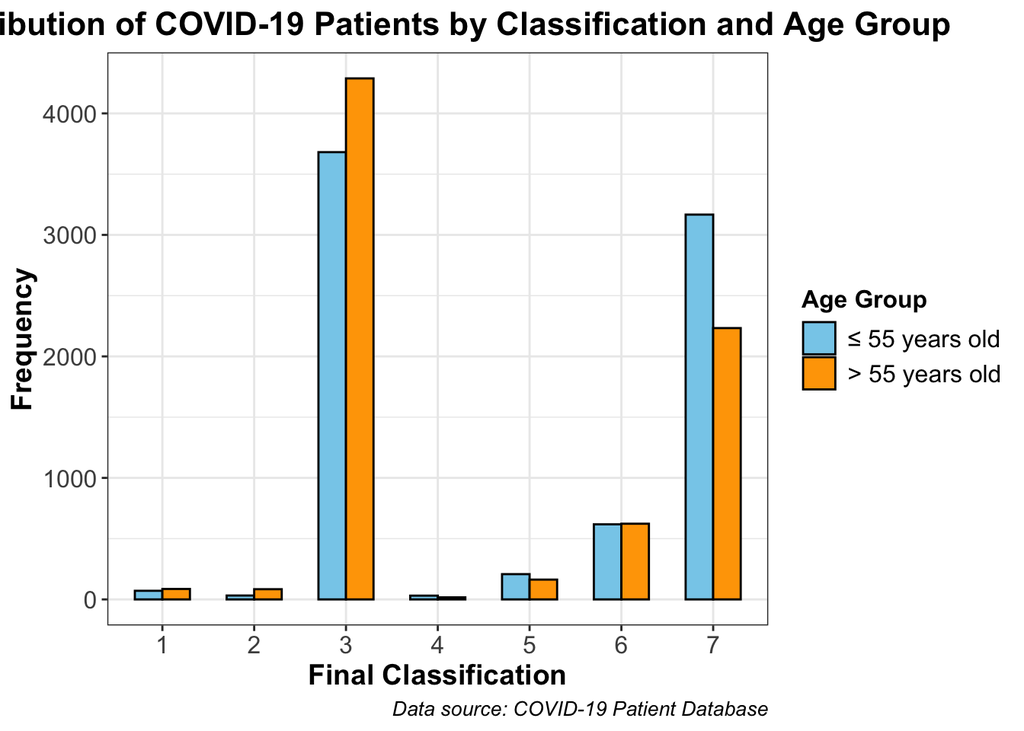

```r
# Load the classification by age group plot
plot_class_age_bar <- readRDS(here::here("output/output_demographic", "plot_class_age_bar.rds"))

# Display the plot
plot_class_age_bar
```

# Comorbidity Analysis

## Counts of Yes and No Responses for Each Condition

This bar chart visualizes the prevalence of various pre-existing health conditions among COVID-19 patients. Each bar represents a condition, with counts for “Yes” (patients with the condition) and “No” (patients without the condition) displayed in red and blue, respectively.

```
## here() starts at /Users/shangjunyao/DATA550/midterm_project
```

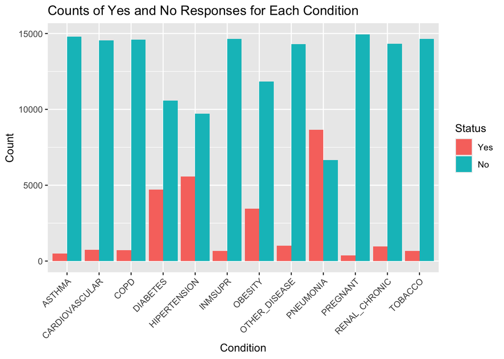

## Summary of Prevalence Table for Pre-Existing Conditions

The prevalence table provides a summary of the number of COVID-19 patients with and without various pre-existing conditions, along with the calculated prevalence of each condition (as a percentage) among the patient population.

```
## # A tibble: 12 × 4
##    condition      Count_Yes Count_No Prevalence_Yes
##    <chr>              <int>    <int>          <dbl>
##  1 ASTHMA               503    14799           3.29
##  2 CARDIOVASCULAR       748    14554           4.89
##  3 COPD                 712    14590           4.65
##  4 DIABETES            4721    10581          30.9
##  5 HIPERTENSION        5585     9717          36.5
##  6 INMSUPR              664    14638           4.34
##  7 OBESITY             3462    11840          22.6
##  8 OTHER_DISEASE       1006    14296           6.57
##  9 PNEUMONIA           8654     6648          56.6
## 10 PREGNANT             363    14939           2.37
## 11 RENAL_CHRONIC        970    14332           6.34
## 12 TOBACCO              659    14643           4.31
```

# Severity and Treatment Type

## Graph 1: Comparing pneumonia and pregnancy data

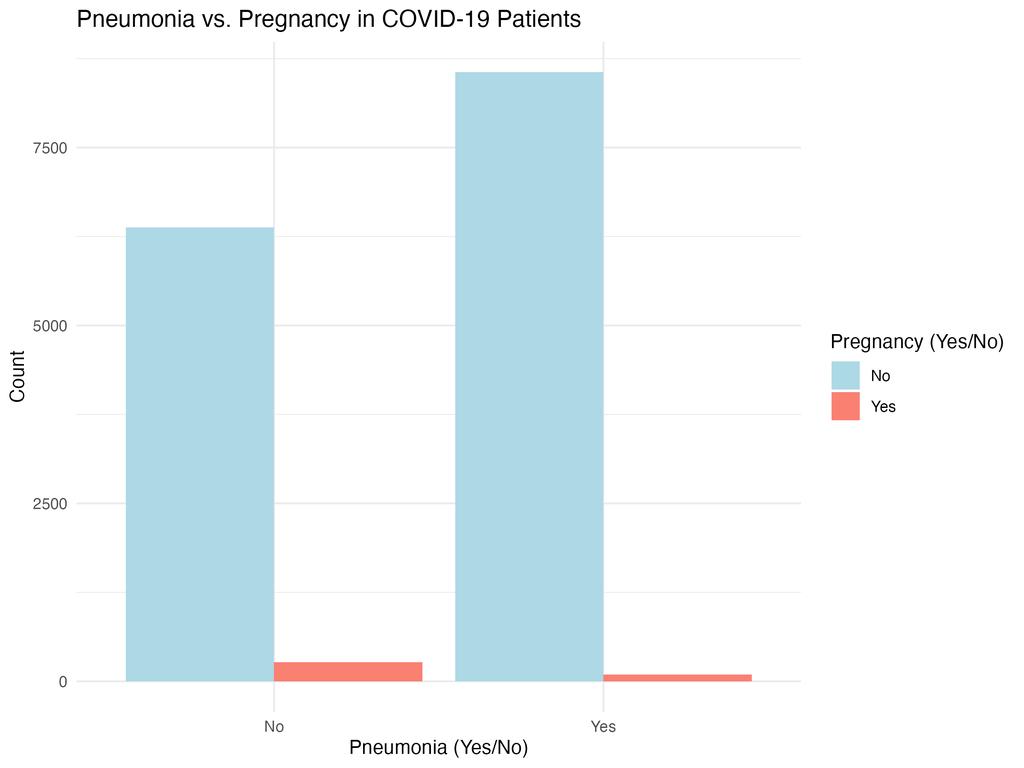

```r
knitr::include_graphics(here::here("output/pneumonia_vs_pregnancy.png"))
```

## Death Status by COVID-19 Severity Classification

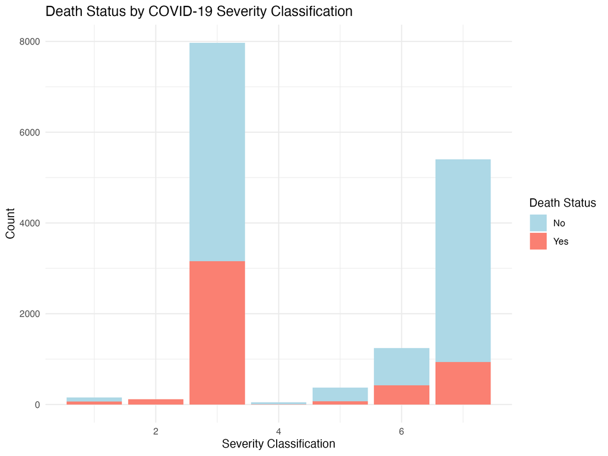

```r
knitr::include_graphics(here::here("output/death_status_by_severity.png"))
```

## Severity Classification by Asthma and Diabetes

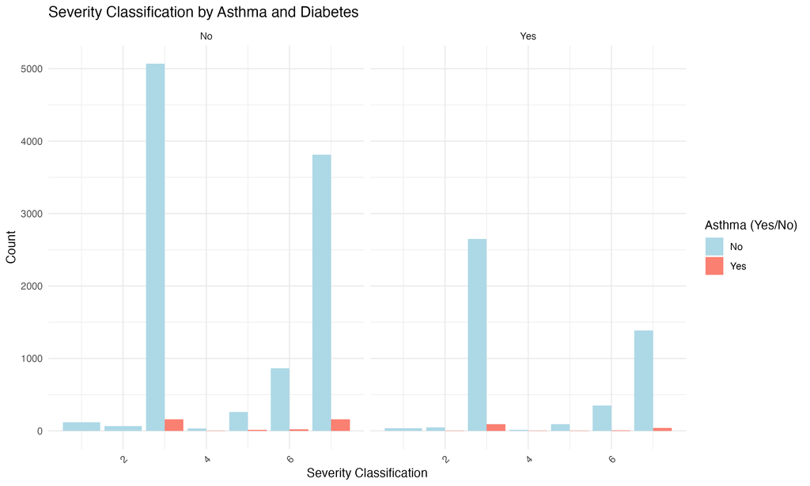

```r
knitr::include_graphics(here::here("output/severity_by_asthma_diabetes.png"))
```

## Classification of COVID-19 Cases (Pie Chart)

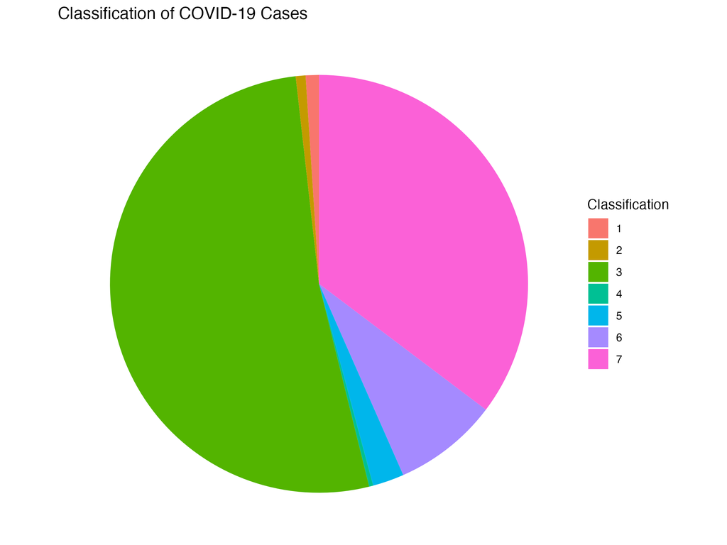

```r
knitr::include_graphics(here::here("output/classification_pie_chart.png"))
```

# Outcome and Mortality Analysis

## Summary of ICU Admission, Intubation, and Mortality Rates

```r
summary_table <- readRDS(here::here("output", "summary_table.rds"))
kable(summary_table, caption = "Summary of ICU Admission, Intubation, and Mortality Rates")
```

Summary of ICU Admission, Intubation, and Mortality Rates

| Metric | Rate |
| --- | --- |
| ICU Admission Rate (No) | 92.282055 |
| ICU Admission Rate (Yes) | 7.717945 |
| Intubation Rate (No) | 84.564109 |
| Intubation Rate (Yes) | 15.435891 |
| Mortality Rate (No) | 68.781859 |
| Mortality Rate (Yes) | 31.218141 |

## Mortality Rate by Pregnancy Status

[figure not shown]

```r
knitr::include_graphics(here::here("output", "mortality_by_pregnancy.png"))
```